# Limits Day 3

## Warm-Up Questions!

1. What is

\begin{equation} \lim_{x \rightarrow 10} \ \frac{-1}{(x-10)^4} \end{equation}

\begin{equation} \lim_{x \rightarrow 10} \ \frac{-1}{(x-10)^4} = -\infty \end{equation}

## Warm-Up Questions!

1. What is

\begin{equation} \lim_{x \rightarrow \infty} \ \log(x) \end{equation}

\begin{equation} \lim_{x \rightarrow \infty} \ \log(x) = \infty \end{equation}

## Warm-Up Questions!

1. What is

\begin{equation} \lim_{x \rightarrow \infty} \ \frac{-(x^3 + 2)}{x^2} \end{equation}

\begin{equation} \lim_{x \rightarrow \infty} \ \frac{-(x^3 + 2)}{x^2} = -\infty \end{equation}

## Converging Functions

So far we've seen graphs that *diverge* as $x$ grows large. Let's look now at some graphs that *converge* as $x$ grows large.

Consider the function

\begin{equation} f(x) = \frac{1}{x} \end{equation}

What happens as $x \rightarrow \infty$?

## Converging Functions

\begin{equation} f(x) = \frac{1}{x} \end{equation}

As $x \rightarrow \infty$, the denominator gets larger and larger and $f(x) \rightarrow 0$. So,

\begin{equation} \lim_{x \rightarrow \infty} \ \frac{1}{x} = 0 \end{equation}

This is different from what we've seen so far!

Our function is *converging* to a value of $0$ as $x$ grows infinitely large!

## Another example

Let's look at another example. Consider the function

\begin{equation} f(x) = \frac{3x^2 + 2x - 5}{x^5} \end{equation}

What happens as $x \rightarrow \infty$?

Like last time, we can just consider the highest order terms. Since $x^5$ grows faster than $x^2$, the denominator is growing faster. Thus

\begin{equation} \lim_{x \rightarrow \infty} \ \frac{3x^2 + 2x - 5}{x^5} = \lim_{x \rightarrow \infty} \ \frac{3x^2}{x^5} = 0 \end{equation}

## Concept Question

True or False: If a function converges to a value, that value will always be zero.

False! Let's look at the function

\begin{equation} f(x) = \frac{2x^3 + 25x - 19352}{x^3 - 5} \end{equation}

When taking the limit, we just consider the highest order terms \begin{equation} \lim_{x \rightarrow \infty} \ f(x) = \lim_{x \rightarrow \infty} \ \frac{2x^3}{x^3} \end{equation}

Now we can ignore any constants \begin{equation} \lim_{x \rightarrow \infty} \ \frac{2x^3}{x^3} = 2 \lim_{x \rightarrow \infty} \ \frac{x^3}{x^3} \end{equation}

That limit is just one! Thus \begin{equation} \lim_{x \rightarrow \infty} \ \frac{2x^3 + 25x - 19352}{x^3 - 5} = 2 \end{equation}

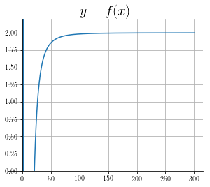

```python
#hideme

import math

def f(x):
    return (2*x**3 + 25*x - 19352)/(x**3 - 5)



def makeArrowY(ax,pos,function,direction):
    delta = 0.0001 if direction >= 0 else -0.01
    ax.arrow(pos,function(pos),delta,function(pos+delta)-function(pos),head_width=0.08,head_length=0.2, color="#1f77b4")

def makeArrowX(ax,pos,function,direction):
    delta = 0.0001 if direction >= 0 else -0.01
    ax.arrow(pos,function(pos),delta,function(pos+delta)-function(pos),head_width=0.5,head_length=2, color="#1f77b4")


fig = plt.figure(figsize=(5, 4))
ax = fig.add_subplot(111)
ax.set_title("$y = f(x)$", fontsize=20)

#xleft = np.arange(-4, 0.99, 0.001)
xright = np.arange(-10, 300, 0.01)
yright = f(xright)
#yleft = f(xleft)
#ax.plot(xleft, yleft)
ax.plot(xright, yright, color="#1f77b4")
ax.set_ylim(0, 2.2)
#ax.yaxis.set_major_locator(ticker.MultipleLocator(1))

#ax.plot(1, 2, marker='o', linewidth=0, markersize=5, markerfacecolor="None",
         #markeredgecolor='black')


#makeArrowX(ax, -2, f, -1)
#makeArrowX(ax, 2, f, 1)


ax.grid(True)

ax.spines['left'].set_position('zero')
ax.spines['right'].set_color('none')
ax.spines['bottom'].set_position('zero')
ax.spines['top'].set_color('none')
ax.xaxis.set_ticks_position('bottom')
ax.yaxis.set_ticks_position('left')
```

## The Overall Rule

When taking \begin{equation} \lim_{x \rightarrow \infty} \ \frac{p(x)}{q(x)} \end{equation}

- If $p(x)$ grows faster than $q(x)$, then the limit diverges to $\pm \infty$
  - Check by either plugging in a value, or looking at the sign of the highest order terms!
- If $q(x)$ grows faster than $p(x)$, then the limit converges to $0$
- If $p(x)$ and $q(x)$ grow at the same rate, then the limit converges to the ratio of the coeffecients of the highest order terms
  - For example, if $p(x) = 7x^5 + 12x^2 - \log(x)$ and $q(x) = 9x^5 - 1321x +25$, then the limit converges to $\frac{7}{9}$

## Let's Practice

In *groups of 3* evaluate the following limits

$\displaystyle\lim_{x \rightarrow \infty} \ \frac{5x^3 - 12x + 21}{7x^3 - 21x + 9}$

$\displaystyle\lim_{x \rightarrow \infty} \ \frac{\log(x) + x}{\log(x)}$

$\displaystyle\lim_{x \rightarrow \infty} \ \frac{2^x}{x^{20}\log(x)}$

$\displaystyle\lim_{x \rightarrow \infty} \ \frac{16\log(x)}{20\log(x)}$

$\displaystyle\lim_{x \rightarrow \infty} \ \frac{2\log(x)}{4\log(x)^2}$

## Let's Practice

In *groups of 3* evaluate the following limits

$\displaystyle\lim_{x \rightarrow \infty} \ \frac{5x^3 - 12x + 21}{7x^3 - 21x + 9} = \frac{5}{7}$

$\displaystyle\lim_{x \rightarrow \infty} \ \frac{\log(x) + x}{\log(x)}$

$\displaystyle\lim_{x \rightarrow \infty} \ \frac{2^x}{x^{20}\log(x)}$

$\displaystyle\lim_{x \rightarrow \infty} \ \frac{16\log(x)}{20\log(x)}$

$\displaystyle\lim_{x \rightarrow \infty} \ \frac{2\log(x)}{4\log(x)^2}$

## Let's Practice

In *groups of 3* evaluate the following limits

$\displaystyle\lim_{x \rightarrow \infty} \ \frac{5x^3 - 12x + 21}{7x^3 - 21x + 9} = \frac{5}{7}$

$\displaystyle\lim_{x \rightarrow \infty} \ \frac{\log(x) + x}{\log(x)} = \infty$

$\displaystyle\lim_{x \rightarrow \infty} \ \frac{2^x}{x^{20}\log(x)}$

$\displaystyle\lim_{x \rightarrow \infty} \ \frac{16\log(x)}{20\log(x)}$

$\displaystyle\lim_{x \rightarrow \infty} \ \frac{2\log(x)}{4\log(x)^2}$

## Let's Practice

In *groups of 3* evaluate the following limits

$\displaystyle\lim_{x \rightarrow \infty} \ \frac{5x^3 - 12x + 21}{7x^3 - 21x + 9} = \frac{5}{7}$

$\displaystyle\lim_{x \rightarrow \infty} \ \frac{\log(x) + x}{\log(x)} = \infty$

$\displaystyle\lim_{x \rightarrow \infty} \ \frac{2^x}{x^{20}\log(x)} = \infty$

$\displaystyle\lim_{x \rightarrow \infty} \ \frac{16\log(x)}{20\log(x)}$

$\displaystyle\lim_{x \rightarrow \infty} \ \frac{2\log(x)}{4\log(x)^2}$

## Let's Practice

In *groups of 3* evaluate the following limits

$\displaystyle\lim_{x \rightarrow \infty} \ \frac{5x^3 - 12x + 21}{7x^3 - 21x + 9} = \frac{5}{7}$

$\displaystyle\lim_{x \rightarrow \infty} \ \frac{\log(x) + x}{\log(x)} = \infty$

$\displaystyle\lim_{x \rightarrow \infty} \ \frac{2^x}{x^{20}\log(x)} = \infty$

$\displaystyle\lim_{x \rightarrow \infty} \ \frac{16\log(x)}{20\log(x)} = \frac{4}{5}$

$\displaystyle\lim_{x \rightarrow \infty} \ \frac{2\log(x)}{4\log(x)^2}$

## Let's Practice

In *groups of 3* evaluate the following limits

$\displaystyle\lim_{x \rightarrow \infty} \ \frac{5x^3 - 12x + 21}{7x^3 - 21x + 9} = \frac{5}{7}$

$\displaystyle\lim_{x \rightarrow \infty} \ \frac{\log(x) + x}{\log(x)} = \infty$

$\displaystyle\lim_{x \rightarrow \infty} \ \frac{2^x}{x^{20}\log(x)} = \infty$

$\displaystyle\lim_{x \rightarrow \infty} \ \frac{16\log(x)}{20\log(x)} = \frac{4}{5}$

$\displaystyle\lim_{x \rightarrow \infty} \ \frac{2\log(x)}{4\log(x)^2} = 0$

## Let's Practice

In *groups of 3* evaluate the following limits

$\displaystyle\lim_{x \rightarrow \infty} \ \frac{1}{(x + 4)}$

$\displaystyle\lim_{x \rightarrow \infty} \ \frac{3e^x + \log(x)}{2e^x + 4x^3}$

$\displaystyle\lim_{x \rightarrow \infty} \ x\log(x)$

$\displaystyle\lim_{x \rightarrow \infty} \ 3$

$\displaystyle\lim_{x \rightarrow \infty} \ \frac{x - \log(x)}{x}$

## Let's Practice

In *groups of 3* evaluate the following limits

$\displaystyle\lim_{x \rightarrow \infty} \ \frac{1}{(x + 4)} = 0$

$\displaystyle\lim_{x \rightarrow \infty} \ \frac{3e^x + \log(x)}{2e^x + 4x^3}$

$\displaystyle\lim_{x \rightarrow \infty} \ x\log(x)$

$\displaystyle\lim_{x \rightarrow \infty} \ 3$

$\displaystyle\lim_{x \rightarrow \infty} \ \frac{x - \log(x)}{x}$

## Let's Practice

In *groups of 3* evaluate the following limits

$\displaystyle\lim_{x \rightarrow \infty} \ \frac{1}{(x + 4)} = 0$

$\displaystyle\lim_{x \rightarrow \infty} \ \frac{3e^x + \log(x)}{2e^x + 4x^3} = \frac{3}{2}$

$\displaystyle\lim_{x \rightarrow \infty} \ x\log(x)$

$\displaystyle\lim_{x \rightarrow \infty} \ 3$

$\displaystyle\lim_{x \rightarrow \infty} \ \frac{x - \log(x)}{x}$

## Let's Practice

In *groups of 3* evaluate the following limits

$\displaystyle\lim_{x \rightarrow \infty} \ \frac{1}{(x + 4)} = 0$

$\displaystyle\lim_{x \rightarrow \infty} \ \frac{3e^x + \log(x)}{2e^x + 4x^3} = \frac{3}{2}$

$\displaystyle\lim_{x \rightarrow \infty} \ x\log(x) = \infty$

$\displaystyle\lim_{x \rightarrow \infty} \ 3$

$\displaystyle\lim_{x \rightarrow \infty} \ \frac{x - \log(x)}{x}$

## Let's Practice

In *groups of 3* evaluate the following limits

$\displaystyle\lim_{x \rightarrow \infty} \ \frac{1}{(x + 4)} = 0$

$\displaystyle\lim_{x \rightarrow \infty} \ \frac{3e^x + \log(x)}{2e^x + 4x^3} = \frac{3}{2}$

$\displaystyle\lim_{x \rightarrow \infty} \ x\log(x) = \infty$

$\displaystyle\lim_{x \rightarrow \infty} \ 3 = 3$

$\displaystyle\lim_{x \rightarrow \infty} \ \frac{x - \log(x)}{x}$

## Let's Practice

In *groups of 3* evaluate the following limits

$\displaystyle\lim_{x \rightarrow \infty} \ \frac{1}{(x + 4)} = 0$

$\displaystyle\lim_{x \rightarrow \infty} \ \frac{3e^x + \log(x)}{2e^x + 4x^3} = \frac{3}{2}$

$\displaystyle\lim_{x \rightarrow \infty} \ x\log(x) = \infty$

$\displaystyle\lim_{x \rightarrow \infty} \ 3 = 3$

$\displaystyle\lim_{x \rightarrow \infty} \ \frac{x - \log(x)}{x} = 1$

## Review

- We have seen how to evaluate a limit at a given point, $\displaystyle\lim_{x \rightarrow a} \ f(x)$
  - First try to directly plug in $a$ and calculate $f(a)$
  - If $f(a)$ is a value, that is the limit.
  - If $f(a)$ is indeterminant, rewrite the limit and re-evaluate
  - If $f(a)$ is not a value but is not indeterminant, it is an asymptote and is either $\pm \infty$ or undefined (in most cases)
- We have also seen how to evaluate a limit at $\infty$, $\displaystyle\lim_{x \rightarrow \infty} \ f(x)$
  - Consider the highest order/fastest growing terms (exponential $>>$ polynomial $>>$ logarithmic)
  - If numerator grows faster, limit diverges
  - If denominator grows faster, limit converges to $0$
  - If both grow at same rate, limit converges to ratio of coeffecients